# 实验一 信用卡欺诈分析

金融学（互联网+金融）1602班 沈吉梅 20160756

## 1. 数据导入

```python
import pandas as pd
creditCardData = pd.read_csv("../input/creditcard.csv")
creditCardData.head()
```

|  | Time | V1 | V2 | V3 | V4 | V5 | V6 | V7 | V8 | V9 | V10 | V11 | V12 | V13 | V14 | V15 | V16 | V17 | V18 | V19 | V20 | V21 | V22 | V23 | V24 | V25 | V26 | V27 | V28 | … |
| --- | --- | --- | --- | --- | --- | --- | --- | --- | --- | --- | --- | --- | --- | --- | --- | --- | --- | --- | --- | --- | --- | --- | --- | --- | --- | --- | --- | --- | --- | --- |
| 0 | 0.0 | -1.359807 | -0.072781 | 2.536347 | 1.378155 | -0.338321 | 0.462388 | 0.239599 | 0.098698 | 0.363787 | 0.090794 | -0.551600 | -0.617801 | -0.991390 | -0.311169 | 1.468177 | -0.470401 | 0.207971 | 0.025791 | 0.403993 | 0.251412 | -0.018307 | 0.277838 | -0.110474 | 0.066928 | 0.128539 | -0.189115 | 0.133558 | -0.021053 | … |
| 1 | 0.0 | 1.191857 | 0.266151 | 0.166480 | 0.448154 | 0.060018 | -0.082361 | -0.078803 | 0.085102 | -0.255425 | -0.166974 | 1.612727 | 1.065235 | 0.489095 | -0.143772 | 0.635558 | 0.463917 | -0.114805 | -0.183361 | -0.145783 | -0.069083 | -0.225775 | -0.638672 | 0.101288 | -0.339846 | 0.167170 | 0.125895 | -0.008983 | 0.014724 | … |
| 2 | 1.0 | -1.358354 | -1.340163 | 1.773209 | 0.379780 | -0.503198 | 1.800499 | 0.791461 | 0.247676 | -1.514654 | 0.207643 | 0.624501 | 0.066084 | 0.717293 | -0.165946 | 2.345865 | -2.890083 | 1.109969 | -0.121359 | -2.261857 | 0.524980 | 0.247998 | 0.771679 | 0.909412 | -0.689281 | -0.327642 | -0.139097 | -0.055353 | -0.059752 | … |
| 3 | 1.0 | -0.966272 | -0.185226 | 1.792993 | -0.863291 | -0.010309 | 1.247203 | 0.237609 | 0.377436 | -1.387024 | -0.054952 | -0.226487 | 0.178228 | 0.507757 | -0.287924 | -0.631418 | -1.059647 | -0.684093 | 1.965775 | -1.232622 | -0.208038 | -0.108300 | 0.005274 | -0.190321 | -1.175575 | 0.647376 | -0.221929 | 0.062723 | 0.061458 | … |
| 4 | 2.0 | -1.158233 | 0.877737 | 1.548718 | 0.403034 | -0.407193 | 0.095921 | 0.592941 | -0.270533 | 0.817739 | 0.753074 | -0.822843 | 0.538196 | 1.345852 | -1.119670 | 0.175121 | -0.451449 | -0.237033 | -0.038195 | 0.803487 | 0.408542 | -0.009431 | 0.798278 | -0.137458 | 0.141267 | -0.206010 | 0.502292 | 0.219422 | 0.215153 | … |

## 2. 数据探索

```python
print (u'实验一的数据集列数是：', len(creditCardData.columns))
creditCardData.describe()
```

```
实验一的数据集列数是： 31
```

|  | Time | V1 | V2 | V3 | V4 | V5 | V6 | V7 | V8 | V9 | V10 | V11 | V12 | V13 | V14 | V15 | V16 | V17 | V18 | V19 | V20 | V21 | V22 | V23 | V24 | V25 | V26 | V27 | V28 | … |
| --- | --- | --- | --- | --- | --- | --- | --- | --- | --- | --- | --- | --- | --- | --- | --- | --- | --- | --- | --- | --- | --- | --- | --- | --- | --- | --- | --- | --- | --- | --- |
| count | 284807.000000 | 2.848070e+05 | 2.848070e+05 | 2.848070e+05 | 2.848070e+05 | 2.848070e+05 | 2.848070e+05 | 2.848070e+05 | 2.848070e+05 | 2.848070e+05 | 2.848070e+05 | 2.848070e+05 | 2.848070e+05 | 2.848070e+05 | 2.848070e+05 | 2.848070e+05 | 2.848070e+05 | 2.848070e+05 | 2.848070e+05 | 2.848070e+05 | 2.848070e+05 | 2.848070e+05 | 2.848070e+05 | 2.848070e+05 | 2.848070e+05 | 2.848070e+05 | 2.848070e+05 | 2.848070e+05 | 2.848070e+05 | … |
| mean | 94813.859575 | 3.919560e-15 | 5.688174e-16 | -8.769071e-15 | 2.782312e-15 | -1.552563e-15 | 2.010663e-15 | -1.694249e-15 | -1.927028e-16 | -3.137024e-15 | 1.768627e-15 | 9.170318e-16 | -1.810658e-15 | 1.693438e-15 | 1.479045e-15 | 3.482336e-15 | 1.392007e-15 | -7.528491e-16 | 4.328772e-16 | 9.049732e-16 | 5.085503e-16 | 1.537294e-16 | 7.959909e-16 | 5.367590e-16 | 4.458112e-15 | 1.453003e-15 | 1.699104e-15 | -3.660161e-16 | -1.206049e-16 | … |
| std | 47488.145955 | 1.958696e+00 | 1.651309e+00 | 1.516255e+00 | 1.415869e+00 | 1.380247e+00 | 1.332271e+00 | 1.237094e+00 | 1.194353e+00 | 1.098632e+00 | 1.088850e+00 | 1.020713e+00 | 9.992014e-01 | 9.952742e-01 | 9.585956e-01 | 9.153160e-01 | 8.762529e-01 | 8.493371e-01 | 8.381762e-01 | 8.140405e-01 | 7.709250e-01 | 7.345240e-01 | 7.257016e-01 | 6.244603e-01 | 6.056471e-01 | 5.212781e-01 | 4.822270e-01 | 4.036325e-01 | 3.300833e-01 | … |
| min | 0.000000 | -5.640751e+01 | -7.271573e+01 | -4.832559e+01 | -5.683171e+00 | -1.137433e+02 | -2.616051e+01 | -4.355724e+01 | -7.321672e+01 | -1.343407e+01 | -2.458826e+01 | -4.797473e+00 | -1.868371e+01 | -5.791881e+00 | -1.921433e+01 | -4.498945e+00 | -1.412985e+01 | -2.516280e+01 | -9.498746e+00 | -7.213527e+00 | -5.449772e+01 | -3.483038e+01 | -1.093314e+01 | -4.480774e+01 | -2.836627e+00 | -1.029540e+01 | -2.604551e+00 | -2.256568e+01 | -1.543008e+01 | … |
| 25% | 54201.500000 | -9.203734e-01 | -5.985499e-01 | -8.903648e-01 | -8.486401e-01 | -6.915971e-01 | -7.682956e-01 | -5.540759e-01 | -2.086297e-01 | -6.430976e-01 | -5.354257e-01 | -7.624942e-01 | -4.055715e-01 | -6.485393e-01 | -4.255740e-01 | -5.828843e-01 | -4.680368e-01 | -4.837483e-01 | -4.988498e-01 | -4.562989e-01 | -2.117214e-01 | -2.283949e-01 | -5.423504e-01 | -1.618463e-01 | -3.545861e-01 | -3.171451e-01 | -3.269839e-01 | -7.083953e-02 | -5.295979e-02 | … |
| 50% | 84692.000000 | 1.810880e-02 | 6.548556e-02 | 1.798463e-01 | -1.984653e-02 | -5.433583e-02 | -2.741871e-01 | 4.010308e-02 | 2.235804e-02 | -5.142873e-02 | -9.291738e-02 | -3.275735e-02 | 1.400326e-01 | -1.356806e-02 | 5.060132e-02 | 4.807155e-02 | 6.641332e-02 | -6.567575e-02 | -3.636312e-03 | 3.734823e-03 | -6.248109e-02 | -2.945017e-02 | 6.781943e-03 | -1.119293e-02 | 4.097606e-02 | 1.659350e-02 | -5.213911e-02 | 1.342146e-03 | 1.124383e-02 | … |
| 75% | 139320.500000 | 1.315642e+00 | 8.037239e-01 | 1.027196e+00 | 7.433413e-01 | 6.119264e-01 | 3.985649e-01 | 5.704361e-01 | 3.273459e-01 | 5.971390e-01 | 4.539234e-01 | 7.395934e-01 | 6.182380e-01 | 6.625050e-01 | 4.931498e-01 | 6.488208e-01 | 5.232963e-01 | 3.996750e-01 | 5.008067e-01 | 4.589494e-01 | 1.330408e-01 | 1.863772e-01 | 5.285536e-01 | 1.476421e-01 | 4.395266e-01 | 3.507156e-01 | 2.409522e-01 | 9.104512e-02 | 7.827995e-02 | … |
| max | 172792.000000 | 2.454930e+00 | 2.205773e+01 | 9.382558e+00 | 1.687534e+01 | 3.480167e+01 | 7.330163e+01 | 1.205895e+02 | 2.000721e+01 | 1.559499e+01 | 2.374514e+01 | 1.201891e+01 | 7.848392e+00 | 7.126883e+00 | 1.052677e+01 | 8.877742e+00 | 1.731511e+01 | 9.253526e+00 | 5.041069e+00 | 5.591971e+00 | 3.942090e+01 | 2.720284e+01 | 1.050309e+01 | 2.252841e+01 | 4.584549e+00 | 7.519589e+00 | 3.517346e+00 | 3.161220e+01 | 3.384781e+01 | … |

```python
creditCardData.isnull().any().sum()
```

```
0
```

数据没有缺失，包含如题目所述的2013年9月2天时间里的284807笔交易数据，题给数据采用PCA变换映射为V1，V2，...，V28 数值型属性，只有交易时间和金额这两个变量没有经过PCA变换。接下来分析一下各个属性之间是否还存在相关性。

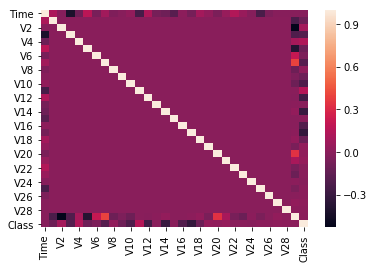

```python
import seaborn as sns
sns.heatmap(creditCardData.corr())
```

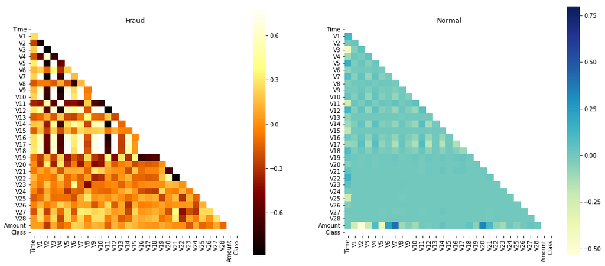

```python
import matplotlib.pyplot as plt
import numpy as np
f, (ax1, ax2) = plt.subplots(1,2,figsize =( 18, 8))
corr = creditCardData.corr()
mask = np.zeros_like(corr, dtype=np.bool)
mask[np.triu_indices_from(mask)] = True
sns.heatmap((creditCardData.loc[creditCardData['Class'] ==1]).corr(), vmax = .8, square=True, ax = ax1, cmap = 'afmhot', mask=mask);
ax1.set_title('Fraud')
sns.heatmap((creditCardData.loc[creditCardData['Class'] ==0]).corr(), vmax = .8, square=True, ax = ax2, cmap = 'YlGnBu', mask=mask);
ax2.set_title('Normal')
plt.show()
```

```
Text(0,0.5,'Frequency')
```

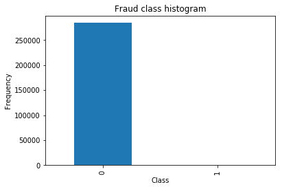

```python
count_classes = pd.value_counts(creditCardData['Class'], sort = True).sort_index()
count_classes.plot(kind = 'bar')
plt.title("Fraud class histogram")
plt.xlabel("Class")
plt.ylabel("Frequency")
```

我们看见，目标变量的分布极不平衡。

## 3. 不同的分类模型

我的第六感告诉我时间和这个模型预测没啥关系，应该drop，但是不能拍脑门，就验证一下女生的第六感吧。

用的方法很navie（严肃脸）。

```python
from sklearn.naive_bayes import GaussianNB
from sklearn.metrics import accuracy_score
col=list(creditCardData.columns.values)
```

```python
def split_data(dataset,ratio):
    sample=np.random.rand(len(dataset))<ratio
    return(dataset[sample],dataset[~sample])
```

```python
creditCardData['Log_Amount']=np.log(creditCardData['Amount']+1)
```

```python
def NB_Classify(ratio,drop_var):
    print('drop:',drop_var)
    pred_acc=[]
    for i in range(10):
        train,test=split_data(creditCardData,ratio)
        clf=GaussianNB()
        clf.fit(train.drop(drop_var,axis=1),train['Class'])
        pred=clf.predict(test.drop(drop_var,axis=1))
        pred_acc.append([pd.crosstab(test['Class'],pred).iloc[1,1]/(pd.crosstab(test['Class'],pred).iloc[1,0]+pd.crosstab(test['Class'],pred).iloc[1,1])])
    print(np.mean(pred_acc))
```

```python
for var in col:
    NB_Classify(0.6,['Class','Log_Amount',var])
```

```
drop: ['Class', 'Log_Amount', 'Time']
0.8180863317194115
drop: ['Class', 'Log_Amount', 'V1']
0.6685005633677322
drop: ['Class', 'Log_Amount', 'V2']
0.6442874009202402
drop: ['Class', 'Log_Amount', 'V3']
0.6360590669758817
drop: ['Class', 'Log_Amount', 'V4']
0.6214282877517492
drop: ['Class', 'Log_Amount', 'V5']
0.6386766307618247
drop: ['Class', 'Log_Amount', 'V6']
0.6384013832293634
drop: ['Class', 'Log_Amount', 'V7']
0.6615048195395943
drop: ['Class', 'Log_Amount', 'V8']
0.6532794476154342
drop: ['Class', 'Log_Amount', 'V9']
0.6530993192178568
drop: ['Class', 'Log_Amount', 'V10']
0.6349249471464151
drop: ['Class', 'Log_Amount', 'V11']
0.641617436312724
drop: ['Class', 'Log_Amount', 'V12']
0.6371575942067661
drop: ['Class', 'Log_Amount', 'V13']
0.6431426738789657
drop: ['Class', 'Log_Amount', 'V14']
0.5955027146715717
drop: ['Class', 'Log_Amount', 'V15']
0.6354816206462579
drop: ['Class', 'Log_Amount', 'V16']
0.654829811789327
drop: ['Class', 'Log_Amount', 'V17']
0.6278132673289237
drop: ['Class', 'Log_Amount', 'V18']
0.6650020823872007
drop: ['Class', 'Log_Amount', 'V19']
0.6389577477176187
drop: ['Class', 'Log_Amount', 'V20']
0.6464060343896247
drop: ['Class', 'Log_Amount', 'V21']
0.6442254635809676
drop: ['Class', 'Log_Amount', 'V22']
0.6438307177427147
drop: ['Class', 'Log_Amount', 'V23']
0.6522211165282632
drop: ['Class', 'Log_Amount', 'V24']
0.6379935467447171
drop: ['Class', 'Log_Amount', 'V25']
0.6589654670341731
drop: ['Class', 'Log_Amount', 'V26']
0.6517586641849358
drop: ['Class', 'Log_Amount', 'V27']
0.6410798122905802
drop: ['Class', 'Log_Amount', 'V28']
0.6402865145845029
drop: ['Class', 'Log_Amount', 'Amount']
0.6375129621822271
drop: ['Class', 'Log_Amount', 'Class']
0.6588656756407356
```

结果很明显的了，要相信女生的第六感，时间没用了。接下来我们正经的分类了。其实通过上面的分析已经有了一个naive的结果，就是朴素贝叶斯可以达到0.8以上。

### （1）SGD

本质上说，这个模型也是一个线性核函数的模型，不同的地方是，它使用了随机梯度下降做训练，所以每次并没有使用全部的样本，收敛速度会快很多。再多提一点，SGDClassifier对于特征的幅度非常敏感，也就是说，我们在把数据灌给它之前，应该先对特征做幅度调整，当然，用sklearn的StandardScaler可以很方便地完成这一点。

```python
from sklearn.preprocessing import StandardScaler
creditCardData['normAmount'] = StandardScaler().fit_transform(creditCardData['Amount'].values.reshape(-1, 1))
creditCardData = creditCardData.drop(['Time','Amount','Log_Amount'],axis=1)
creditCardData.head()
```

|  | V1 | V2 | V3 | V4 | V5 | V6 | V7 | V8 | V9 | V10 | V11 | V12 | V13 | V14 | V15 | V16 | V17 | V18 | V19 | V20 | V21 | V22 | V23 | V24 | V25 | V26 | V27 | V28 | Class | … |
| --- | --- | --- | --- | --- | --- | --- | --- | --- | --- | --- | --- | --- | --- | --- | --- | --- | --- | --- | --- | --- | --- | --- | --- | --- | --- | --- | --- | --- | --- | --- |
| 0 | -1.359807 | -0.072781 | 2.536347 | 1.378155 | -0.338321 | 0.462388 | 0.239599 | 0.098698 | 0.363787 | 0.090794 | -0.551600 | -0.617801 | -0.991390 | -0.311169 | 1.468177 | -0.470401 | 0.207971 | 0.025791 | 0.403993 | 0.251412 | -0.018307 | 0.277838 | -0.110474 | 0.066928 | 0.128539 | -0.189115 | 0.133558 | -0.021053 | 0 | … |
| 1 | 1.191857 | 0.266151 | 0.166480 | 0.448154 | 0.060018 | -0.082361 | -0.078803 | 0.085102 | -0.255425 | -0.166974 | 1.612727 | 1.065235 | 0.489095 | -0.143772 | 0.635558 | 0.463917 | -0.114805 | -0.183361 | -0.145783 | -0.069083 | -0.225775 | -0.638672 | 0.101288 | -0.339846 | 0.167170 | 0.125895 | -0.008983 | 0.014724 | 0 | … |
| 2 | -1.358354 | -1.340163 | 1.773209 | 0.379780 | -0.503198 | 1.800499 | 0.791461 | 0.247676 | -1.514654 | 0.207643 | 0.624501 | 0.066084 | 0.717293 | -0.165946 | 2.345865 | -2.890083 | 1.109969 | -0.121359 | -2.261857 | 0.524980 | 0.247998 | 0.771679 | 0.909412 | -0.689281 | -0.327642 | -0.139097 | -0.055353 | -0.059752 | 0 | … |
| 3 | -0.966272 | -0.185226 | 1.792993 | -0.863291 | -0.010309 | 1.247203 | 0.237609 | 0.377436 | -1.387024 | -0.054952 | -0.226487 | 0.178228 | 0.507757 | -0.287924 | -0.631418 | -1.059647 | -0.684093 | 1.965775 | -1.232622 | -0.208038 | -0.108300 | 0.005274 | -0.190321 | -1.175575 | 0.647376 | -0.221929 | 0.062723 | 0.061458 | 0 | … |
| 4 | -1.158233 | 0.877737 | 1.548718 | 0.403034 | -0.407193 | 0.095921 | 0.592941 | -0.270533 | 0.817739 | 0.753074 | -0.822843 | 0.538196 | 1.345852 | -1.119670 | 0.175121 | -0.451449 | -0.237033 | -0.038195 | 0.803487 | 0.408542 | -0.009431 | 0.798278 | -0.137458 | 0.141267 | -0.206010 | 0.502292 | 0.219422 | 0.215153 | 0 | … |

```python
from sklearn.model_selection import train_test_split
X = creditCardData.iloc[:, creditCardData.columns != 'Class']
y = creditCardData.iloc[:, creditCardData.columns == 'Class']
X_train, X_test, y_train, y_test = train_test_split(X,y,test_size = 0.3, random_state = 0)
```

```python
X_train.shape
```

```
(199364, 29)
```

```python
X_test.shape
```

```
(85443, 29)
```

```python
from sklearn.pipeline import Pipeline
from sklearn.preprocessing import StandardScaler
from sklearn.linear_model import SGDClassifier
```

```python
param_grid_sgd = [{
    'model__loss': ['log'],
    'model__penalty': ['l1', 'l2'],
    'model__alpha': np.logspace(start=-3, stop=3, num=20)
}, {
    'model__loss': ['hinge'],
    'model__alpha': np.logspace(start=-3, stop=3, num=20),
    'model__class_weight': [None, 'balanced']
}]
```

```python
pipeline_sgd = Pipeline([
    ('scaler', StandardScaler(copy=False)),
    ('model', SGDClassifier(max_iter=1000, tol=1e-3, random_state=1, warm_start=True))
])
```

```python
from sklearn.model_selection import GridSearchCV
from sklearn.metrics import make_scorer, matthews_corrcoef
```

```python
MCC_scorer = make_scorer(matthews_corrcoef)
sgd = GridSearchCV(estimator=pipeline_sgd, param_grid=param_grid_sgd, scoring=MCC_scorer, n_jobs=-1, pre_dispatch='2*n_jobs', cv=5, verbose=1, return_train_score=False)
```

```python
import warnings
with warnings.catch_warnings(): # Suppress warnings from the matthews_corrcoef function
    warnings.simplefilter("ignore")
    sgd.fit(X_train, y_train)
```

```
Fitting 5 folds for each of 80 candidates, totalling 400 fits
```

```
[Parallel(n_jobs=-1)]: Using backend LokyBackend with 4 concurrent workers.
[Parallel(n_jobs=-1)]: Done  42 tasks      | elapsed:   20.9s
[Parallel(n_jobs=-1)]: Done 192 tasks      | elapsed:  1.3min
[Parallel(n_jobs=-1)]: Done 400 out of 400 | elapsed:  2.3min finished
```

```python
sgd.best_score_
```

```
0.8171411260956134
```

```python
sgd.best_params_
```

```
{'model__alpha': 483.2930238571752,
 'model__class_weight': 'balanced',
 'model__loss': 'hinge'}
```

### （2） Decision Tree Classifier

这似乎是我们目前为止唯一学过的分类器了，好像得用一下？试探一下

```python
from sklearn.tree import DecisionTreeClassifier
```

先试探一下模型参数

```python
deep=np.array(range(1,20))
xvalMSE =[]
score_hist=[]
for ideep in deep:
    dt=DecisionTreeClassifier(max_depth = ideep)
    dt.fit(X_train,y_train)
    pred=dt.predict(X_test)
    pred=np.array(pred,dtype=np.float32)
    y_tst=np.array(y_test,dtype=np.float32)
    error=[y_tst[r] - pred[r] for r in range(len(y_tst))]
    o_error=sum(e*e for e in error)
    mse=o_error/len(y_test)
    print(mse)
    xvalMSE.append(mse)
```

```
[0.000948]
[0.00077244]
[0.00076074]
[0.00076074]
[0.00074904]
[0.00067882]
[0.00069052]
[0.00074904]
[0.00076074]
[0.00069052]
[0.00078415]
[0.00072563]
[0.00077244]
[0.00080756]
[0.00088948]
[0.00091289]
[0.0009363]
[0.00102993]
[0.00090119]
```

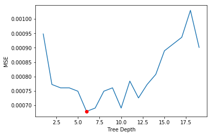

```python
plt.figure()
plt.plot(deep,xvalMSE)
plt.xlabel("Tree Depth")
plt.ylabel("MSE")
opt_depth = deep[np.argmin(xvalMSE)]
plt.plot(opt_depth,np.amin(xvalMSE),"or")
```

```python
print(opt_depth)
```

```
6
```

```python
pipeline_dt = Pipeline([
    ('model', DecisionTreeClassifier(max_depth = opt_depth))
])
```

```python
param_grid_dt = {}
```

```python
dt = GridSearchCV(estimator=pipeline_dt, param_grid=param_grid_dt, scoring=MCC_scorer, n_jobs=-1, pre_dispatch='2*n_jobs', cv=5, verbose=1, return_train_score=False)
```

```python
dt.fit(X_train,y_train)
```

```
Fitting 5 folds for each of 1 candidates, totalling 5 fits
```

```
[Parallel(n_jobs=-1)]: Using backend LokyBackend with 4 concurrent workers.
[Parallel(n_jobs=-1)]: Done   5 out of   5 | elapsed:   11.1s finished
```

```
GridSearchCV(cv=5, error_score='raise-deprecating',
       estimator=Pipeline(memory=None,
     steps=[('model', DecisionTreeClassifier(class_weight=None, criterion='gini', max_depth=6,
            max_features=None, max_leaf_nodes=None,
            min_impurity_decrease=0.0, min_impurity_split=None,
            min_samples_leaf=1, min_samples_split=2,
            min_weight_fraction_leaf=0.0, presort=False, random_state=None,
            splitter='best'))]),
       fit_params=None, iid='warn', n_jobs=-1, param_grid={},
       pre_dispatch='2*n_jobs', refit=True, return_train_score=False,
       scoring=make_scorer(matthews_corrcoef), verbose=1)
```

```python
dt.best_score_
```

```
0.8301964466388098
```

emmmmm...一棵树可能不够用，接着我们请出一堆树

### （3）Random Forest

```python
from sklearn.ensemble import RandomForestClassifier
```

```python
pipeline_rf = Pipeline([
    ('model', RandomForestClassifier(n_jobs=-1, random_state=1))
])
```

```python
param_grid_rf = {'model__n_estimators': [75]}
```

```python
rf = GridSearchCV(estimator=pipeline_rf, param_grid=param_grid_rf, scoring=MCC_scorer, n_jobs=-1, pre_dispatch='2*n_jobs', cv=5, verbose=1, return_train_score=False)
```

```python
rf.fit(X_train, y_train)
```

```
Fitting 5 folds for each of 1 candidates, totalling 5 fits
```

```
[Parallel(n_jobs=-1)]: Using backend LokyBackend with 4 concurrent workers.
[Parallel(n_jobs=-1)]: Done   5 out of   5 | elapsed:  3.1min finished
```

```
GridSearchCV(cv=5, error_score='raise-deprecating',
       estimator=Pipeline(memory=None,
     steps=[('model', RandomForestClassifier(bootstrap=True, class_weight=None, criterion='gini',
            max_depth=None, max_features='auto', max_leaf_nodes=None,
            min_impurity_decrease=0.0, min_impurity_split=None,
            min_samples_leaf=1, min_samples_split=2,
            min_weight_fraction_leaf=0.0, n_estimators='warn', n_jobs=-1,
            oob_score=False, random_state=1, verbose=0, warm_start=False))]),
       fit_params=None, iid='warn', n_jobs=-1,
       param_grid={'model__n_estimators': [75]}, pre_dispatch='2*n_jobs',
       refit=True, return_train_score=False,
       scoring=make_scorer(matthews_corrcoef), verbose=1)
```

```python
rf.best_score_
```

```
0.8555440170842182
```

是不是优秀多了呢？hhh

```python
import itertools
from sklearn.metrics import confusion_matrix, classification_report, matthews_corrcoef, cohen_kappa_score, accuracy_score, average_precision_score, roc_auc_score
```

```python
def plot_confusion_matrix(cm, classes,
                          normalize=False,
                          title='Confusion matrix',
                          cmap=plt.cm.Blues):

    plt.imshow(cm, interpolation='nearest', cmap=cmap)
    plt.title(title)
    plt.colorbar()
    tick_marks = np.arange(len(classes))
    plt.xticks(tick_marks, classes, rotation=45)
    plt.yticks(tick_marks, classes)

    if normalize:
        cm = cm.astype('float') / cm.sum(axis=1)[:, np.newaxis]

    thresh = cm.max() / 2.
    for i, j in itertools.product(range(cm.shape[0]), range(cm.shape[1])):
        plt.text(j, i, cm[i, j],
                 horizontalalignment="center",
                 color="white" if cm[i, j] > thresh else "black")

    plt.tight_layout()
    plt.ylabel('True label')
    plt.xlabel('Predicted label')
```

```python
def classification_eval(estimator, X_test, y_test):
    y_pred = estimator.predict(X_test)
    dec = np.int64(np.ceil(np.log10(len(y_test))))

    print('CONFUSION MATRIX')
    cfm=confusion_matrix(y_test, y_pred)
    plot_confusion_matrix(cfm, classes = range(2))
    plt.show()
    print('CLASSIFICATION REPORT')
    print(classification_report(y_test, y_pred, digits=dec))
    print('SCALAR METRICS')
    format_str = '%%13s = %%.%if' % dec
    print(format_str % ('MCC', matthews_corrcoef(y_test, y_pred)))
    print(format_str % ('AUPRC', average_precision_score(y_test, estimator.predict_proba(X_test)[:,1])))
    print(format_str % ('AUROC', roc_auc_score(y_test, estimator.predict_proba(X_test)[:,1])))
    print(format_str % ("Cohen's kappa", cohen_kappa_score(y_test, y_pred)))
    print(format_str % ('Accuracy', accuracy_score(y_test, y_pred)))
```

```
CONFUSION MATRIX
```

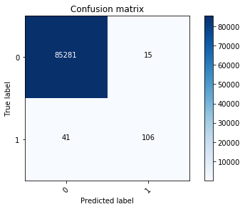

```
CLASSIFICATION REPORT
              precision    recall  f1-score   support

           0    0.99952   0.99982   0.99967     85296
           1    0.87603   0.72109   0.79104       147

   micro avg    0.99934   0.99934   0.99934     85443
   macro avg    0.93778   0.86046   0.89536     85443
weighted avg    0.99931   0.99934   0.99931     85443

SCALAR METRICS
          MCC = 0.79448
        AUPRC = 0.81086
        AUROC = 0.93243
Cohen's kappa = 0.79072
     Accuracy = 0.99934
```

```python
classification_eval(rf, X_test, y_test)
```

### （4）NN

老师提了就试试，不过我能力有限，水平一般。

```python
creditCardData = pd.read_csv('../input/creditcard.csv')
```

```python
from sklearn.preprocessing import StandardScaler
creditCardData['normAmount'] = StandardScaler().fit_transform(creditCardData['Amount'].values.reshape(-1, 1))
creditCardData = creditCardData.drop(['Time','Amount'],axis=1)
creditCardData.head()
```

|  | V1 | V2 | V3 | V4 | V5 | V6 | V7 | V8 | V9 | V10 | V11 | V12 | V13 | V14 | V15 | V16 | V17 | V18 | V19 | V20 | V21 | V22 | V23 | V24 | V25 | V26 | V27 | V28 | Class | … |
| --- | --- | --- | --- | --- | --- | --- | --- | --- | --- | --- | --- | --- | --- | --- | --- | --- | --- | --- | --- | --- | --- | --- | --- | --- | --- | --- | --- | --- | --- | --- |
| 0 | -1.359807 | -0.072781 | 2.536347 | 1.378155 | -0.338321 | 0.462388 | 0.239599 | 0.098698 | 0.363787 | 0.090794 | -0.551600 | -0.617801 | -0.991390 | -0.311169 | 1.468177 | -0.470401 | 0.207971 | 0.025791 | 0.403993 | 0.251412 | -0.018307 | 0.277838 | -0.110474 | 0.066928 | 0.128539 | -0.189115 | 0.133558 | -0.021053 | 0 | … |
| 1 | 1.191857 | 0.266151 | 0.166480 | 0.448154 | 0.060018 | -0.082361 | -0.078803 | 0.085102 | -0.255425 | -0.166974 | 1.612727 | 1.065235 | 0.489095 | -0.143772 | 0.635558 | 0.463917 | -0.114805 | -0.183361 | -0.145783 | -0.069083 | -0.225775 | -0.638672 | 0.101288 | -0.339846 | 0.167170 | 0.125895 | -0.008983 | 0.014724 | 0 | … |
| 2 | -1.358354 | -1.340163 | 1.773209 | 0.379780 | -0.503198 | 1.800499 | 0.791461 | 0.247676 | -1.514654 | 0.207643 | 0.624501 | 0.066084 | 0.717293 | -0.165946 | 2.345865 | -2.890083 | 1.109969 | -0.121359 | -2.261857 | 0.524980 | 0.247998 | 0.771679 | 0.909412 | -0.689281 | -0.327642 | -0.139097 | -0.055353 | -0.059752 | 0 | … |
| 3 | -0.966272 | -0.185226 | 1.792993 | -0.863291 | -0.010309 | 1.247203 | 0.237609 | 0.377436 | -1.387024 | -0.054952 | -0.226487 | 0.178228 | 0.507757 | -0.287924 | -0.631418 | -1.059647 | -0.684093 | 1.965775 | -1.232622 | -0.208038 | -0.108300 | 0.005274 | -0.190321 | -1.175575 | 0.647376 | -0.221929 | 0.062723 | 0.061458 | 0 | … |
| 4 | -1.158233 | 0.877737 | 1.548718 | 0.403034 | -0.407193 | 0.095921 | 0.592941 | -0.270533 | 0.817739 | 0.753074 | -0.822843 | 0.538196 | 1.345852 | -1.119670 | 0.175121 | -0.451449 | -0.237033 | -0.038195 | 0.803487 | 0.408542 | -0.009431 | 0.798278 | -0.137458 | 0.141267 | -0.206010 | 0.502292 | 0.219422 | 0.215153 | 0 | … |

```python
X = creditCardData.iloc[:, creditCardData.columns != 'Class']
y = creditCardData.iloc[:, creditCardData.columns == 'Class']
```

```python
from sklearn.model_selection import train_test_split
X_train, X_test, y_train, y_test = train_test_split(X,y,test_size=0.3)
```

```python
print(np.shape(X_train))
print(np.shape(y_train))
print(np.shape(X_test))
print(np.shape(y_test))
```

```
(199364, 29)
(199364, 1)
(85443, 29)
(85443, 1)
```

```python
from keras.models import Sequential
from keras.layers import Dense
from keras.layers import Dropout
from keras.utils import to_categorical
```

```python
NN = Sequential()
NN.add(Dense(units=9,kernel_initializer='uniform',activation='relu',input_dim=29))
NN.add(Dropout(rate=0.1))
NN.add(Dense(units=9,kernel_initializer='uniform',activation='relu',input_dim=29))
NN.add(Dropout(rate=0.1))
NN.add(Dense(units=1,kernel_initializer='uniform',activation='sigmoid'))
NN.compile(optimizer = 'adam', loss = 'binary_crossentropy', metrics = ['accuracy'])
```

```python
NN.fit(X_train,y_train,batch_size=10,epochs=5)
```

```
<keras.callbacks.History at 0x7f7c1d439860>
```

```python
score, acc = NN.evaluate(X_test, y_test)
print('Test score:', score)
print('Test accuracy:', acc)
```

```
Test score: 0.003070598533971743
Test accuracy: 0.9995084442259752
```

```python
history = NN.fit(X_train, y_train, batch_size = 2048, epochs = 20,
         validation_data = (X_test, y_test), verbose = 2)
```

```
Train on 199364 samples, validate on 85443 samples
 - 0s - loss: 0.0037 - acc: 0.9993 - val_loss: 0.0029 - val_acc: 0.9995
 - 0s - loss: 0.0036 - acc: 0.9994 - val_loss: 0.0028 - val_acc: 0.9995
 - 0s - loss: 0.0036 - acc: 0.9994 - val_loss: 0.0026 - val_acc: 0.9995
 - 0s - loss: 0.0034 - acc: 0.9994 - val_loss: 0.0026 - val_acc: 0.9995
 - 0s - loss: 0.0034 - acc: 0.9994 - val_loss: 0.0025 - val_acc: 0.9995
 - 0s - loss: 0.0034 - acc: 0.9993 - val_loss: 0.0025 - val_acc: 0.9995
 - 0s - loss: 0.0035 - acc: 0.9994 - val_loss: 0.0024 - val_acc: 0.9995
 - 0s - loss: 0.0034 - acc: 0.9994 - val_loss: 0.0024 - val_acc: 0.9995
 - 0s - loss: 0.0035 - acc: 0.9994 - val_loss: 0.0024 - val_acc: 0.9995
 - 0s - loss: 0.0033 - acc: 0.9994 - val_loss: 0.0024 - val_acc: 0.9995
 - 0s - loss: 0.0034 - acc: 0.9994 - val_loss: 0.0024 - val_acc: 0.9995
 - 0s - loss: 0.0033 - acc: 0.9994 - val_loss: 0.0024 - val_acc: 0.9995
 - 0s - loss: 0.0034 - acc: 0.9994 - val_loss: 0.0024 - val_acc: 0.9995
 - 0s - loss: 0.0032 - acc: 0.9994 - val_loss: 0.0024 - val_acc: 0.9995
 - 0s - loss: 0.0034 - acc: 0.9994 - val_loss: 0.0024 - val_acc: 0.9995
 - 0s - loss: 0.0034 - acc: 0.9994 - val_loss: 0.0024 - val_acc: 0.9995
 - 0s - loss: 0.0033 - acc: 0.9994 - val_loss: 0.0024 - val_acc: 0.9995
 - 0s - loss: 0.0033 - acc: 0.9994 - val_loss: 0.0024 - val_acc: 0.9995
 - 0s - loss: 0.0034 - acc: 0.9993 - val_loss: 0.0024 - val_acc: 0.9995
 - 0s - loss: 0.0035 - acc: 0.9994 - val_loss: 0.0024 - val_acc: 0.9995
```

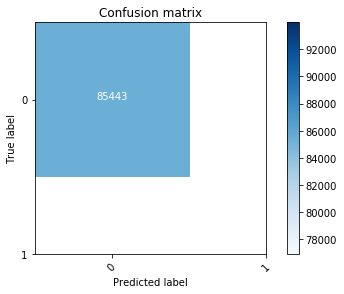

```python
y_pred = NN.predict(X_test)
y_pred_classes = np.argmax(y_pred,axis = 1)
y_true = np.argmax(y_test,axis = 1)
confusion_mtx = confusion_matrix(y_true, y_pred_classes)
plot_confusion_matrix(confusion_mtx, classes = range(2))
plt.show()
```